# Cars4U Case Study - Connie Xavier

## Problem Definition and Information

### Context

There is a huge demand for pre-owned cars over new cars in the Indian Market, as used car sales have surpassed new car sales in the last few years. Used cars have more uncertainty in pricing and supply over new cars. Understanding the factors that affect pricing is important as the pre-owned market grows.

As a senior data scientist at Cars4U, I have to come up with a pricing model that can effectively predict the price of used cars and can help the business in devising profitable strategies using differential pricing.

### Objective

To analyze, visualize, and preprocess the data, build a linear regression model to predict the price of used cars, and gather insights and recommendations for the business.

### Key Questions

1. What are the key factors influencing the price of a used car?
2. Is there a good linear regression model for the price of a used car? What does the performance assessment look like for such a model?

### Data Information

Each record in the database represents attributes of a used car sold. A detailed data dictionary can be found below.

**Data Dictionary**

- S.No.: Serial number
- Name: Name of the car which includes brand name and model name
- Location: Location in which the car is being sold or is available for purchase
- Year: Manufacturing year of the car
- Kilometers_driven: The total kilometers (a unit used to measure length or distance) driven in the car by the previous owner(s)
- Fuel_Type: The type of fuel used by the car (Petrol, Diesel, Electric, CNG, LPG)
- Transmission: The type of transmission used by the car (Automatic/Manual)
- Owner: Type of ownership
- Mileage: The standard mileage offered by the car company in kmpl or km/kg
- Engine: The displacement volume of the engine in CC
- Power: The maximum power of the engine in bhp
- Seats: The number of seats in the car
- New_Price: The price of a new car of the same model in INR Lakhs (1 Lakh INR = 100,000 INR)
- Price: The price of the used car in INR Lakhs

# ---------------------------------------------------------------------------------------------------------------

## Part 1: Overview of Data

```python
# import relevant libraries

# this will help in making the Python code more structured automatically (good coding practice)
%load_ext nb_black

# Libraries to help with reading and manipulating data
import numpy as np
import pandas as pd

# Libraries to help with data visualization
import matplotlib.pyplot as plt
import seaborn as sns

%matplotlib inline

sns.set()

# Removes the limit for the number of displayed columns
pd.set_option("display.max_columns", None)
# Sets the limit for the number of displayed rows
pd.set_option("display.max_rows", 200)

# to split the data into train and test
from sklearn.model_selection import train_test_split

# to build linear regression_model
from sklearn.linear_model import LinearRegression

# to check model performance
from sklearn.metrics import mean_absolute_error, mean_squared_error, r2_score
```

```
The nb_black extension is already loaded. To reload it, use:
  %reload_ext nb_black
```

```python
# load the data
data = pd.read_csv("used_cars_data.csv")
```

```python
# check a sample of the data to make sure it came in correctly
data.sample(n=10, random_state=101)
```

|  | S.No. | Name | Location | Year | Kilometers_Driven | Fuel_Type | Transmission | Owner_Type | Mileage | Engine | Power | Seats | New_Price | Price |
| --- | --- | --- | --- | --- | --- | --- | --- | --- | --- | --- | --- | --- | --- | --- |
| 4464 | 4464 | Hyundai i20 1.2 Magna Executive | Delhi | 2017 | 17431 | Petrol | Manual | First | 18.6 kmpl | 1197 CC | 81.83 bhp | 5.0 | 10.250 | 6.00 |
| 5845 | 5845 | BMW 5 Series 525d Sedan | Mumbai | 2013 | 35000 | Diesel | Automatic | First | 16.73 kmpl | 2993 CC | 218 bhp | 5.0 | 67.870 | 21.00 |
| 829 | 829 | Toyota Etios Liva G | Mumbai | 2012 | 29605 | Petrol | Manual | First | 18.3 kmpl | 1197 CC | NaN | 5.0 | 8.525 | 2.44 |
| 5531 | 5531 | Toyota Innova 2.5 V Diesel 8-seater | Hyderabad | 2011 | 144471 | Diesel | Manual | First | 12.8 kmpl | 2494 CC | 102 bhp | 8.0 | 24.010 | 7.80 |
| 1251 | 1251 | Hyundai i10 Sportz | Delhi | 2013 | 62334 | Petrol | Manual | First | 20.36 kmpl | 1197 CC | 78.9 bhp | 5.0 | 10.250 | 2.75 |
| 3412 | 3412 | Toyota Etios G | Kochi | 2013 | 56344 | Petrol | Manual | First | 17.6 kmpl | 1496 CC | 88.73 bhp | 5.0 | 8.525 | 4.57 |
| 1377 | 1377 | Honda City i DTec V | Coimbatore | 2017 | 73003 | Diesel | Manual | First | 26.0 kmpl | 1498 CC | 98.6 bhp | 5.0 | 13.580 | 7.75 |
| 3773 | 3773 | Hyundai Grand i10 AT Asta | Chennai | 2015 | 15000 | Petrol | Automatic | First | 18.9 kmpl | 1197 CC | 82 bhp | 5.0 | 7.450 | 5.50 |
| 5310 | 5310 | Volkswagen Polo 1.5 TDI Highline | Chennai | 2017 | 25000 | Diesel | Manual | First | 20.14 kmpl | 1498 CC | 88 bhp | 5.0 | 9.970 | 6.90 |
| 2422 | 2422 | Jaguar XJ 3.0L Portfolio | Delhi | 2016 | 12000 | Diesel | Automatic | First | 10.5 kmpl | 2993 CC | 271.23 bhp | 4.0 | 69.675 | 79.00 |

- Looks like all the features came in.
- S. No. appears to be the same as the index.
- Some of the columns have units in them (Mileage, Engine, Power), so we will have to preprocess it to remove the unit information.
- There are some missing values in the data.

```python
# check the shape
print(f"There are {data.shape[0]} rows and {data.shape[1]} columns in the data.")
```

```
There are 7253 rows and 14 columns in the data.
```

```python
# checking for duplicate values in the data
print(f"There are {data.duplicated().sum()} duplicated rows in the data.")
```

```
There are 0 duplicated rows in the data.
```

```python
# check datatypes of the columns and which columns have null values
data.info()
```

```
<class 'pandas.core.frame.DataFrame'>
RangeIndex: 7253 entries, 0 to 7252
Data columns (total 14 columns):
 #   Column             Non-Null Count  Dtype
---  ------             --------------  -----
 0   S.No.              7253 non-null   int64
 1   Name               7253 non-null   object
 2   Location           7253 non-null   object
 3   Year               7253 non-null   int64
 4   Kilometers_Driven  7253 non-null   int64
 5   Fuel_Type          7253 non-null   object
 6   Transmission       7253 non-null   object
 7   Owner_Type         7253 non-null   object
 8   Mileage            7251 non-null   object
 9   Engine             7207 non-null   object
 10  Power              7078 non-null   object
 11  Seats              7200 non-null   float64
 12  New_Price          7253 non-null   float64
 13  Price              6019 non-null   float64
dtypes: float64(3), int64(3), object(8)
memory usage: 793.4+ KB
```

- The Mileage, Engine, Power, Seats, and Price columns have null values.
- The dependent variable, Price, is of float type.
- The other numeric columns are S. No., Year, Kilometers_Driven, Seats, and New_Price.
- All other columns are of object datatype.
- Fuel, Transmission, and Owner_type should be category datatypes. Mileage, Engine, and Power need to be converted to numeric datatypes.

```python
# check number of null values in each column
data.isnull().sum()[data.isnull().sum() > 0]
```

```
Mileage       2
Engine       46
Power       175
Seats        53
Price      1234
dtype: int64
```

The dependent variable, Price, has the highest number of missing values, followed by Power, Seats, Engine, and Mileage.

```python
# check the percent of missing data for each column
((data.isnull().sum()[data.isnull().sum() > 0]) / data.shape[0]) * 100
```

```
Mileage     0.027575
Engine      0.634220
Power       2.412795
Seats       0.730732
Price      17.013650
dtype: float64
```

The missing values for Mileage, Engine, and Seats make up less than 1% of the column.

```python
# look at the statistical summary of the data
data.describe(include="all").T
```

|  | count | unique | top | freq | mean | std | min | 25% | 50% | 75% | max |
| --- | --- | --- | --- | --- | --- | --- | --- | --- | --- | --- | --- |
| S.No. | 7253.0 | NaN | NaN | NaN | 3626.0 | 2093.905084 | 0.0 | 1813.0 | 3626.0 | 5439.0 | 7252.0 |
| Name | 7253 | 2041 | Mahindra XUV500 W8 2WD | 55 | NaN | NaN | NaN | NaN | NaN | NaN | NaN |
| Location | 7253 | 11 | Mumbai | 949 | NaN | NaN | NaN | NaN | NaN | NaN | NaN |
| Year | 7253.0 | NaN | NaN | NaN | 2013.365366 | 3.254421 | 1996.0 | 2011.0 | 2014.0 | 2016.0 | 2019.0 |
| Kilometers_Driven | 7253.0 | NaN | NaN | NaN | 58699.063146 | 84427.720583 | 171.0 | 34000.0 | 53416.0 | 73000.0 | 6500000.0 |
| Fuel_Type | 7253 | 5 | Diesel | 3852 | NaN | NaN | NaN | NaN | NaN | NaN | NaN |
| Transmission | 7253 | 2 | Manual | 5204 | NaN | NaN | NaN | NaN | NaN | NaN | NaN |
| Owner_Type | 7253 | 4 | First | 5952 | NaN | NaN | NaN | NaN | NaN | NaN | NaN |
| Mileage | 7251 | 450 | 17.0 kmpl | 207 | NaN | NaN | NaN | NaN | NaN | NaN | NaN |
| Engine | 7207 | 150 | 1197 CC | 732 | NaN | NaN | NaN | NaN | NaN | NaN | NaN |
| Power | 7078 | 385 | 74 bhp | 280 | NaN | NaN | NaN | NaN | NaN | NaN | NaN |
| Seats | 7200.0 | NaN | NaN | NaN | 5.279722 | 0.81166 | 0.0 | 5.0 | 5.0 | 5.0 | 10.0 |
| New_Price | 7253.0 | NaN | NaN | NaN | 21.307322 | 24.256314 | 3.91 | 7.88 | 11.3 | 21.69 | 375.0 |
| Price | 6019.0 | NaN | NaN | NaN | 9.479468 | 11.187917 | 0.44 | 3.5 | 5.64 | 9.95 | 160.0 |

- The Price of used cars covers a wide range, from 0.44 to 160 INR Lakhs, but the median is on the lower end at 5.64.
- The S.No. ranges from 0 to 7252, equal to the index of the dataframe.
- There are 2,041 unique names of cars which may be too many to create dummy variables for.
- There are only 11 unique values in Location column which means cities.
- The cars were manufactured between 1996 and 2019, with most being manufactured in the 2010s.
- The max number of kilometers driven is 6,500,000.
  - This seems very large and may be an outlier.
- Mileage, Engine, and Power need to be pre-processed to get more information.
- The min value for Seats is 0.
  - This seems unreasonable, and could be an outlier.
- The mean price of new cars is around 21.31 INR Lakhs.

```python
# look at value counts of the categorical variables to make sure they take on an expected range of values
cat_col = ["Name", "Location", "Fuel_Type", "Transmission", "Owner_Type"]

# printing the number of occurrences of each unique value in each categorical column
for column in cat_col:
    print(f"Column name: {column}")
    print(data[column].value_counts(dropna=False, normalize=True))
    print("-" * 50)
```

```
Column name: Name
Mahindra XUV500 W8 2WD                  0.007583
Maruti Swift VDI                        0.006756
Maruti Swift Dzire VDI                  0.005791
Honda City 1.5 S MT                     0.005377
Maruti Swift VDI BSIV                   0.005101
                                          ...
Chevrolet Beat LT Option                0.000138
Skoda Rapid 1.6 MPI AT Elegance Plus    0.000138
Ford EcoSport 1.5 TDCi Ambiente         0.000138
Hyundai i10 Magna 1.1 iTech SE          0.000138
Hyundai Elite i20 Magna Plus            0.000138
Name: Name, Length: 2041, dtype: float64
--------------------------------------------------
Column name: Location
Mumbai        0.130842
Hyderabad     0.120778
Coimbatore    0.106439
Kochi         0.106439
Pune          0.105474
Delhi         0.090997
Kolkata       0.090170
Chennai       0.081484
Jaipur        0.068799
Bangalore     0.060665
Ahmedabad     0.037915
Name: Location, dtype: float64
--------------------------------------------------
Column name: Fuel_Type
Diesel      0.531091
Petrol      0.458431
CNG         0.008548
LPG         0.001654
Electric    0.000276
Name: Fuel_Type, dtype: float64
--------------------------------------------------
Column name: Transmission
Manual       0.717496
Automatic    0.282504
Name: Transmission, dtype: float64
--------------------------------------------------
Column name: Owner_Type
First             0.820626
Second            0.158831
Third             0.018889
Fourth & Above    0.001654
Name: Owner_Type, dtype: float64
--------------------------------------------------
```

- The possible values for each category are reasonable.
- Most used cars are sold in Mumbai, diesel fuel type, manual transmission, and first ownership.

```python
# check the name column to see if we may want to keep this in our analysis
# let's see how many unique car makes are there
data["Name"].str.lower().str.strip().str.split(expand=True)[0].value_counts()
```

```
maruti           1444
hyundai          1340
honda             743
toyota            507
mercedes-benz     380
volkswagen        374
ford              351
mahindra          331
bmw               312
audi              285
tata              228
skoda             202
renault           170
chevrolet         151
nissan            117
land               67
jaguar             48
fiat               38
mitsubishi         36
mini               31
volvo              28
porsche            19
jeep               19
datsun             17
isuzu               5
force               3
bentley             2
smart               1
ambassador          1
lamborghini         1
hindustan           1
opelcorsa           1
Name: 0, dtype: int64
```

Looks like we could do an analysis of the make of used cars as it decreases the number of dummy variables we need.

## Part 2: Data Preprocessing and Exploratory Data Analysis

Data preprocessing and EDA go hand-in-hand, as treating outliers and missing values can affect the distribution and relationships between variables.

## Data Format Check - Dimension, Types

### Drop irrelevant columns.

```python
# copy the data to avoid any changes to the original data
df = data.copy()
# drop irrelevant columns - serial number does not give useful information
df.drop(axis=1, inplace=True, columns="S.No.")
df.columns
```

```
Index(['Name', 'Location', 'Year', 'Kilometers_Driven', 'Fuel_Type',
       'Transmission', 'Owner_Type', 'Mileage', 'Engine', 'Power', 'Seats',
       'New_Price', 'Price'],
      dtype='object')
```

### Deal with missing values in target variable.

```python
# drop null values in the Price column since it is the target variable
df.dropna(subset=["Price"], inplace=True)
df.shape
```

```
(6019, 13)
```

```python
# reset the dataframe index
df.reset_index(inplace=True, drop=True)
```

### Convert any incorrect datatypes.

```python
# Mileage, Engine, and Power need to be converted to the numeric datatype.
# Let's look at Mileage first
df["Mileage"].str.lower().str.strip().str.split(expand=True)[1].value_counts()
```

```
kmpl     5951
km/kg      66
Name: 1, dtype: int64
```

There are only 2 types of units in the Mileage column. kmpl and km/kg are units associated with different types of fuel, but both the units refer to the distance covered (in km) per unit of fuel, so we don't need to conver the units.

```python
# convert Mileage column to numeric
def tonumeric(var):
    if isinstance(var, str):  # checking if the value is string or not
        return float(
            var.lower().strip().split()[0]
        )  # splitting the value by space and taking the first part
    else:
        return np.nan  # will return NaN if value is not string


df["Mileage"] = df["Mileage"].apply(tonumeric)
df.sample(n=5, random_state=101)
```

|  | Name | Location | Year | Kilometers_Driven | Fuel_Type | Transmission | Owner_Type | Mileage | Engine | Power | Seats | New_Price | Price |
| --- | --- | --- | --- | --- | --- | --- | --- | --- | --- | --- | --- | --- | --- |
| 2530 | BMW 5 Series 520d Sedan | Kochi | 2014 | 64158 | Diesel | Automatic | First | 18.48 | NaN | NaN | NaN | 67.87 | 17.89 |
| 2745 | Maruti Vitara Brezza ZDi Plus | Kochi | 2017 | 38426 | Diesel | Manual | First | 24.30 | 1248 CC | 88.5 bhp | 5.0 | 11.12 | 9.13 |
| 5674 | Skoda Octavia Elegance 1.8 TSI AT | Kochi | 2017 | 30523 | Petrol | Automatic | First | 14.70 | 1798 CC | 177.5 bhp | 5.0 | 25.83 | 17.08 |
| 54 | Hyundai Grand i10 Sportz | Chennai | 2015 | 54000 | Petrol | Manual | Third | 18.90 | 1197 CC | 82 bhp | 5.0 | 7.45 | 3.60 |
| 1489 | Volkswagen Vento Petrol Highline | Pune | 2013 | 57197 | Petrol | Manual | First | 15.04 | 1598 CC | 103.6 bhp | 5.0 | 13.23 | 4.00 |

Mileage column has been converted sucessfully.

```python
# let's look at Engine column next
df["Engine"].str.lower().str.strip().str.split(expand=True)[1].value_counts()
```

```
cc    5983
Name: 1, dtype: int64
```

All the Engine column values end in 'cc' so we can convert it to numeric similarly as we did the Mileage.

```python
# convert Engine column to numeric
df["Engine"] = df["Engine"].apply(tonumeric)
df.sample(n=5, random_state=101)
```

|  | Name | Location | Year | Kilometers_Driven | Fuel_Type | Transmission | Owner_Type | Mileage | Engine | Power | Seats | New_Price | Price |
| --- | --- | --- | --- | --- | --- | --- | --- | --- | --- | --- | --- | --- | --- |
| 2530 | BMW 5 Series 520d Sedan | Kochi | 2014 | 64158 | Diesel | Automatic | First | 18.48 | NaN | NaN | NaN | 67.87 | 17.89 |
| 2745 | Maruti Vitara Brezza ZDi Plus | Kochi | 2017 | 38426 | Diesel | Manual | First | 24.30 | 1248.0 | 88.5 bhp | 5.0 | 11.12 | 9.13 |
| 5674 | Skoda Octavia Elegance 1.8 TSI AT | Kochi | 2017 | 30523 | Petrol | Automatic | First | 14.70 | 1798.0 | 177.5 bhp | 5.0 | 25.83 | 17.08 |
| 54 | Hyundai Grand i10 Sportz | Chennai | 2015 | 54000 | Petrol | Manual | Third | 18.90 | 1197.0 | 82 bhp | 5.0 | 7.45 | 3.60 |
| 1489 | Volkswagen Vento Petrol Highline | Pune | 2013 | 57197 | Petrol | Manual | First | 15.04 | 1598.0 | 103.6 bhp | 5.0 | 13.23 | 4.00 |

```python
# look at the Power column
df["Power"].str.lower().str.strip().str.split(expand=True)[1].value_counts()
```

```
bhp    5876
Name: 1, dtype: int64
```

All the Power column values end in bhp, so we can convert it to numeric datatype similar to the other columns.

```python
# convert Power column to numeric
df["Power"] = df["Power"].apply(tonumeric)
df.sample(n=5, random_state=101)
```

|  | Name | Location | Year | Kilometers_Driven | Fuel_Type | Transmission | Owner_Type | Mileage | Engine | Power | Seats | New_Price | Price |
| --- | --- | --- | --- | --- | --- | --- | --- | --- | --- | --- | --- | --- | --- |
| 2530 | BMW 5 Series 520d Sedan | Kochi | 2014 | 64158 | Diesel | Automatic | First | 18.48 | NaN | NaN | NaN | 67.87 | 17.89 |
| 2745 | Maruti Vitara Brezza ZDi Plus | Kochi | 2017 | 38426 | Diesel | Manual | First | 24.30 | 1248.0 | 88.5 | 5.0 | 11.12 | 9.13 |
| 5674 | Skoda Octavia Elegance 1.8 TSI AT | Kochi | 2017 | 30523 | Petrol | Automatic | First | 14.70 | 1798.0 | 177.5 | 5.0 | 25.83 | 17.08 |
| 54 | Hyundai Grand i10 Sportz | Chennai | 2015 | 54000 | Petrol | Manual | Third | 18.90 | 1197.0 | 82.0 | 5.0 | 7.45 | 3.60 |
| 1489 | Volkswagen Vento Petrol Highline | Pune | 2013 | 57197 | Petrol | Manual | First | 15.04 | 1598.0 | 103.6 | 5.0 | 13.23 | 4.00 |

```python
# convert categorical variables to "category" datatype
df[["Name", "Location", "Fuel_Type", "Transmission", "Owner_Type"]] = df[
    ["Name", "Location", "Fuel_Type", "Transmission", "Owner_Type"]
].astype("category")
df.info()
```

```
<class 'pandas.core.frame.DataFrame'>
RangeIndex: 6019 entries, 0 to 6018
Data columns (total 13 columns):
 #   Column             Non-Null Count  Dtype
---  ------             --------------  -----
 0   Name               6019 non-null   category
 1   Location           6019 non-null   category
 2   Year               6019 non-null   int64
 3   Kilometers_Driven  6019 non-null   int64
 4   Fuel_Type          6019 non-null   category
 5   Transmission       6019 non-null   category
 6   Owner_Type         6019 non-null   category
 7   Mileage            6017 non-null   float64
 8   Engine             5983 non-null   float64
 9   Power              5876 non-null   float64
 10  Seats              5977 non-null   float64
 11  New_Price          6019 non-null   float64
 12  Price              6019 non-null   float64
dtypes: category(5), float64(6), int64(2)
memory usage: 491.7 KB
```

All the data types look correct now.

### Evaluate additional columns that could be helpful in the analysis.

```python
# create copy of df
df1 = df.copy()
```

```python
# extract the make from the Name column
df1["Make"] = df1["Name"].str.lower().str.strip().str.split(" ", 1, expand=True)[0]
df1["Make"]
```

```
0          maruti
1         hyundai
2           honda
3          maruti
4            audi
          ...
6014       maruti
6015      hyundai
6016     mahindra
6017       maruti
6018    chevrolet
Name: Make, Length: 6019, dtype: object
```

```python
# convert added columns to category datatype
df1["Make"] = df1["Make"].astype("category")
```

```python
# check the head
df1.head()
```

|  | Name | Location | Year | Kilometers_Driven | Fuel_Type | Transmission | Owner_Type | Mileage | Engine | Power | Seats | New_Price | Price | Make |
| --- | --- | --- | --- | --- | --- | --- | --- | --- | --- | --- | --- | --- | --- | --- |
| 0 | Maruti Wagon R LXI CNG | Mumbai | 2010 | 72000 | CNG | Manual | First | 26.60 | 998.0 | 58.16 | 5.0 | 5.51 | 1.75 | maruti |
| 1 | Hyundai Creta 1.6 CRDi SX Option | Pune | 2015 | 41000 | Diesel | Manual | First | 19.67 | 1582.0 | 126.20 | 5.0 | 16.06 | 12.50 | hyundai |
| 2 | Honda Jazz V | Chennai | 2011 | 46000 | Petrol | Manual | First | 18.20 | 1199.0 | 88.70 | 5.0 | 8.61 | 4.50 | honda |
| 3 | Maruti Ertiga VDI | Chennai | 2012 | 87000 | Diesel | Manual | First | 20.77 | 1248.0 | 88.76 | 7.0 | 11.27 | 6.00 | maruti |
| 4 | Audi A4 New 2.0 TDI Multitronic | Coimbatore | 2013 | 40670 | Diesel | Automatic | Second | 15.20 | 1968.0 | 140.80 | 5.0 | 53.14 | 17.74 | audi |

```python
# check column names and data types
df1.info()
```

```
<class 'pandas.core.frame.DataFrame'>
RangeIndex: 6019 entries, 0 to 6018
Data columns (total 14 columns):
 #   Column             Non-Null Count  Dtype
---  ------             --------------  -----
 0   Name               6019 non-null   category
 1   Location           6019 non-null   category
 2   Year               6019 non-null   int64
 3   Kilometers_Driven  6019 non-null   int64
 4   Fuel_Type          6019 non-null   category
 5   Transmission       6019 non-null   category
 6   Owner_Type         6019 non-null   category
 7   Mileage            6017 non-null   float64
 8   Engine             5983 non-null   float64
 9   Power              5876 non-null   float64
 10  Seats              5977 non-null   float64
 11  New_Price          6019 non-null   float64
 12  Price              6019 non-null   float64
 13  Make               6019 non-null   category
dtypes: category(6), float64(6), int64(2)
memory usage: 498.8 KB
```

## Univariate Analysis

Perform univariate analysis to see which columns have outliers. Let's look at numerical columns first.

```python
# function to plot a boxplot and a histogram along the same scale.


def histogram_boxplot(data, feature, figsize=(12, 7), kde=True, bins=None):
    """
    Boxplot and histogram combined

    data: dataframe
    feature: dataframe column
    figsize: size of figure (default (12,7))
    kde: whether to the show density curve (default False)
    bins: number of bins for histogram (default None)
    """
    f2, (ax_box2, ax_hist2) = plt.subplots(
        nrows=2,  # Number of rows of the subplot grid= 2
        sharex=True,  # x-axis will be shared among all subplots
        gridspec_kw={"height_ratios": (0.25, 0.75)},
        figsize=figsize,
    )  # creating the 2 subplots
    sns.boxplot(
        data=data, x=feature, ax=ax_box2, showmeans=True, color="violet"
    )  # boxplot will be created and a star will indicate the mean value of the column
    sns.histplot(
        data=data, x=feature, kde=kde, ax=ax_hist2, bins=bins, palette="winter"
    ) if bins else sns.histplot(
        data=data, x=feature, kde=kde, ax=ax_hist2
    )  # For histogram
    ax_hist2.axvline(
        data[feature].mean(), color="green", linestyle="--"
    )  # Add mean to the histogram
    ax_hist2.axvline(
        data[feature].median(), color="black", linestyle="-"
    )  # Add median to the histogram
```

### `Price`

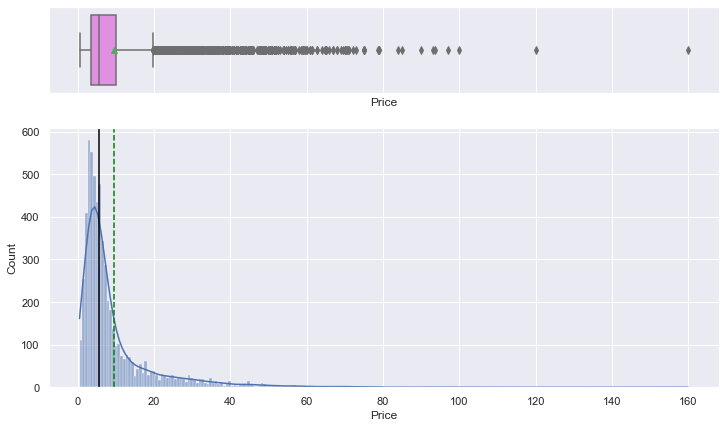

```python
histogram_boxplot(df1, "Price")
```

- The target variable Price is skewed to the right. The mean is greater than the median.
- We can try transforming this distribution to look more normal.
- There are a few very expensive cars, we will want to check if these are outliers.

### `Year`

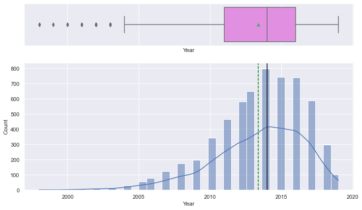

```python
histogram_boxplot(df1, "Year")
```

- The distribution is skewed to the left a little, but the mean and median are close to each other.
- There are some outliers to the left, but no point is too extreme from the others.

### `Kilometers_Driven`

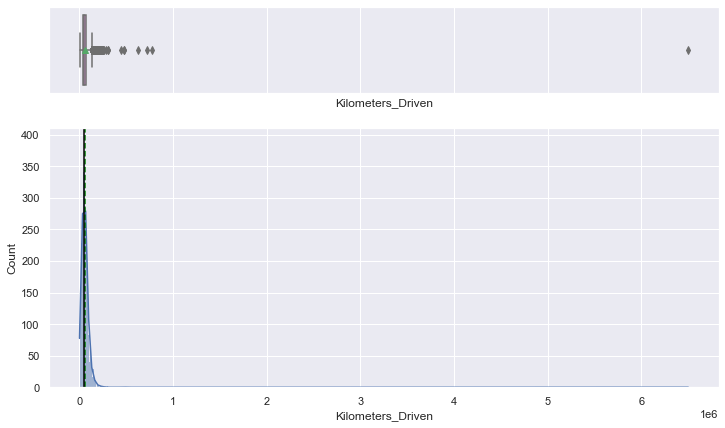

```python
histogram_boxplot(df1, "Kilometers_Driven")
```

- The distribution is highly skewed to the right, and there is one or more points that is much farther away than the others.
- This point could be an outlier we would want to drop.

### `Mileage`

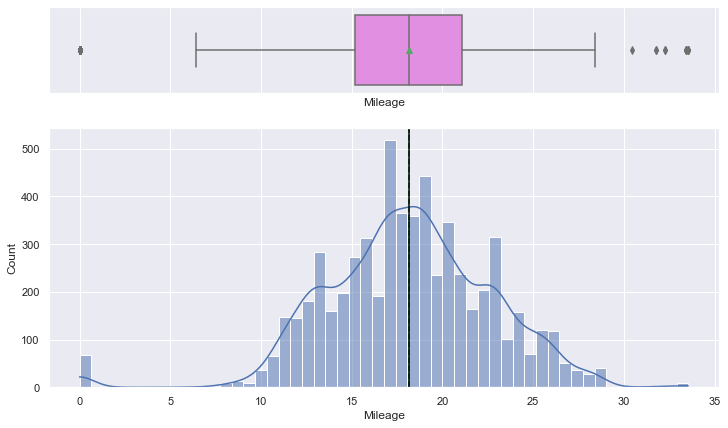

```python
histogram_boxplot(df1, "Mileage")
```

- The Mileage columns is very closely normally distributed, with a few outliers on both sides.
- The mean and median are close to each other, so imputing with the mean is an option for this variable.
- Some points are at 0 - we would want to further analyze this.

### `Engine`

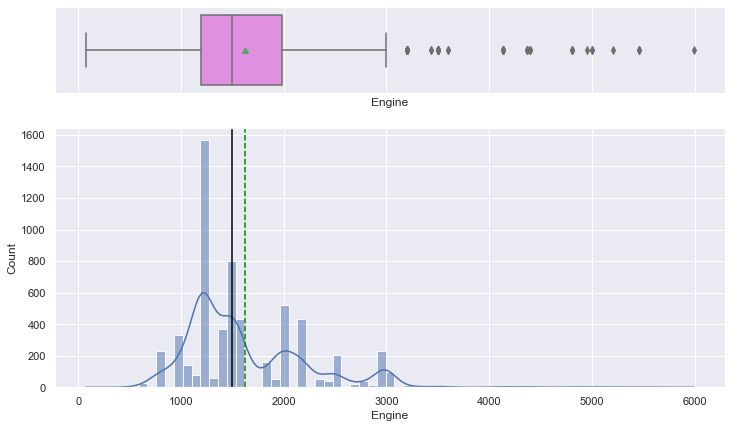

```python
histogram_boxplot(df1, "Engine")
```

- The distribution is skewed to the right.

### `Power`

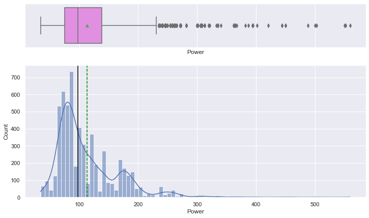

```python
histogram_boxplot(df1, "Power")
```

- The distribution is skewed to the right.
- The median power is around 100.

### `Seats`

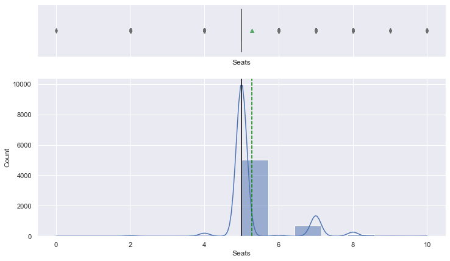

```python
histogram_boxplot(df1, "Seats")
```

- Most used cars have 5 seats.
- Number of seats ranges from 0 to 10. We will want to check if the min and max are reasonable.

### `New Price`

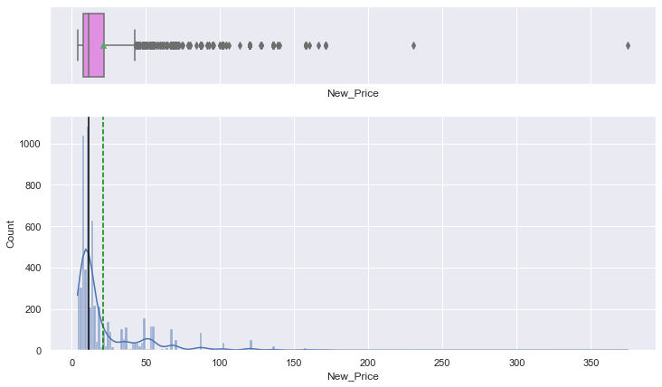

```python
histogram_boxplot(df1, "New_Price")
```

- The price of new cars are heavily right skewed.
- There are a couple of points that are much further than the others. These could be true outliers we will want to look at.

Now, look at categorical variables.

```python
# function to create labeled barplots


def labeled_barplot(data, feature, perc=False, n=None):
    """
    Barplot with percentage at the top

    data: dataframe
    feature: dataframe column
    perc: whether to display percentages instead of count (default is False)
    n: displays the top n category levels (default is None, i.e., display all levels)
    """

    total = len(data[feature])  # length of the column
    count = data[feature].nunique()
    if n is None:
        plt.figure(figsize=(count + 1, 5))
    else:
        plt.figure(figsize=(n + 1, 5))

    plt.xticks(rotation=90, fontsize=15)
    ax = sns.countplot(
        data=data,
        x=feature,
        palette="Paired",
        order=data[feature].value_counts().index[:n],
    )

    for p in ax.patches:
        if perc == True:
            label = "{:.1f}%".format(
                100 * p.get_height() / total
            )  # percentage of each class of the category
        else:
            label = p.get_height()  # count of each level of the category

        x = p.get_x() + p.get_width() / 2  # width of the plot
        y = p.get_height()  # height of the plot

        ax.annotate(
            label,
            (x, y),
            ha="center",
            va="center",
            size=12,
            xytext=(0, 5),
            textcoords="offset points",
        )  # annotate the percentage

    plt.show()  # show the plot
```

### `Location`

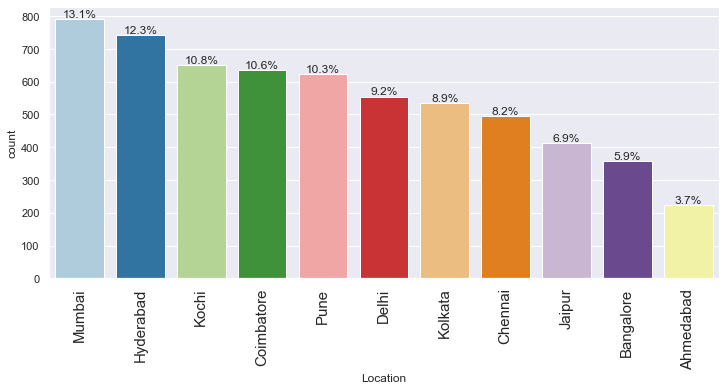

```python
labeled_barplot(data=df1, feature="Location", perc=True)
```

- Mumbi and Hyderbad have the higher share in used cars sold.
- Ahmedabad has the lowest number of used cars sold.

### `Fuel_Type`

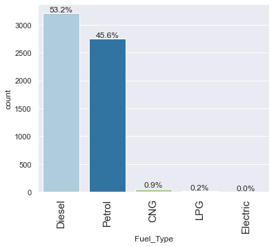

```python
labeled_barplot(data=df1, feature="Fuel_Type", perc=True)
```

- The majority of used cars are Diesel fuel.
- There is a close split between Diesel and Petrol fuel types.
- LPG, CNG, and Electric make up less than 1% each of the used cars.

### `Transmission`

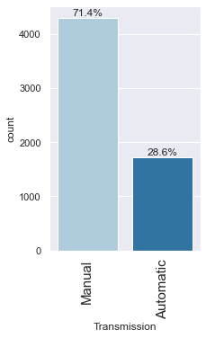

```python
labeled_barplot(data=df1, feature="Transmission", perc=True)
```

- Majority of used cars sold have a Manual transmission.

### `Owner_Type`

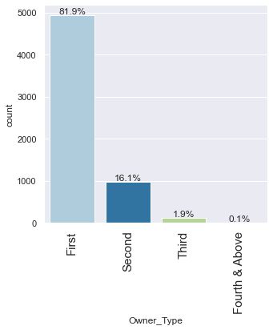

```python
labeled_barplot(data=df1, feature="Owner_Type", perc=True)
```

- Most used cars sold are from the first owner of the car.
- There is a huge drop in percentage from first ownership to second ownership.
- Very few are selling their car as the third or above owner.

### `Make`

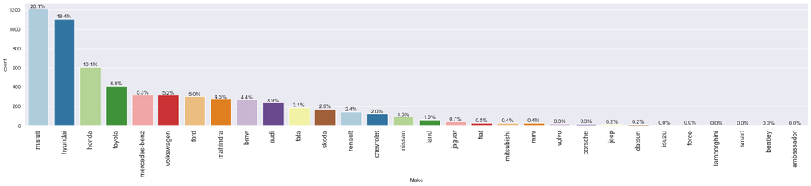

```python
labeled_barplot(data=df1, feature="Make", perc=True)
```

- The most popular used car brands are Maruti and Hyundai - together they make up almost 39% of the data.
- There are 6 car brands that make up less than 0.1% each of the share.

## Data Consistency - Outlier Treatment

It's important to treat true outliers as that will affect the relationship between the target variable and other variables. After looking at the univariate distributions, we noticed there are outliers in the data.

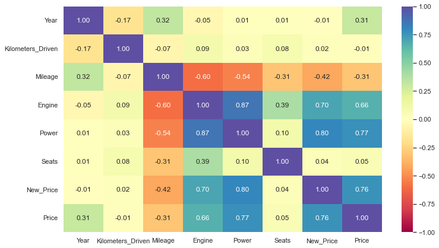

```python
# check the correlation of variables to see which ones we can use to impute outliers
df2 = df1.copy()
corr_cols = df2.dtypes[(df2.dtypes == np.number) | (df2.dtypes == np.int64)].index
plt.figure(figsize=(12, 7))
sns.heatmap(
    df2[corr_cols].corr(), annot=True, vmin=-1, vmax=1, fmt=".2f", cmap="Spectral"
)
```

- Price is highly correlated with New_Price and Power.
- Power and Engine are highly correlated.
- Mileage is highly correlated with Engine and Power.

```python
# look at Price column. There were a few very expensive cars. let's look at the most expenisve cars
df2.sort_values(by="Price", ascending=False).head(3)
```

|  | Name | Location | Year | Kilometers_Driven | Fuel_Type | Transmission | Owner_Type | Mileage | Engine | Power | Seats | New_Price | Price | Make |
| --- | --- | --- | --- | --- | --- | --- | --- | --- | --- | --- | --- | --- | --- | --- |
| 4079 | Land Rover Range Rover 3.0 Diesel LWB Vogue | Hyderabad | 2017 | 25000 | Diesel | Automatic | First | 13.33 | 2993.0 | 255.0 | 5.0 | 230.000 | 160.0 | land |
| 5781 | Lamborghini Gallardo Coupe | Delhi | 2011 | 6500 | Petrol | Automatic | Third | 6.40 | 5204.0 | 560.0 | 2.0 | 11.300 | 120.0 | lamborghini |
| 5919 | Jaguar F Type 5.0 V8 S | Hyderabad | 2015 | 8000 | Petrol | Automatic | First | 12.50 | 5000.0 | 488.1 | 2.0 | 69.675 | 100.0 | jaguar |

- The first car's Price is a lot higher than the other car prices, as seen by the box plot earlier. It would be best to drop this value, as used car prices this high are rare in the data.
- The second row shows a huge difference between the new and used car price. Let's explore that more, since it shouldn't be so far apart.

```python
# drop the car with the highest price
df2.drop(axis=0, index=4079, inplace=True)
```

```
5781    10.619469
5423     2.243902
3622     2.084878
2259     2.048780
5743     2.016585
dtype: float64
```

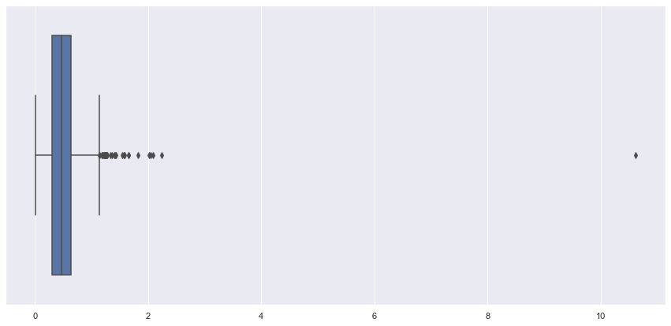

```python
# find the fraction of the used car price vs. new car price. let's see how many points are extreme
print((df2["Price"] / df2["New_Price"]).sort_values(ascending=False).head())
plt.figure(figsize=(15, 7))
sns.boxplot(data=df2, x=(df2["Price"] / df2["New_Price"]))
```

Only one point goes as high as 10.

```python
# filter data set for values that are less than 10
df2 = df2[df2["Price"] / df2["New_Price"] < 10]
```

```python
# let's look at the cheapest cars
df2.sort_values(by="Price", ascending=True).head(3)
```

|  | Name | Location | Year | Kilometers_Driven | Fuel_Type | Transmission | Owner_Type | Mileage | Engine | Power | Seats | New_Price | Price | Make |
| --- | --- | --- | --- | --- | --- | --- | --- | --- | --- | --- | --- | --- | --- | --- |
| 1713 | Tata Nano Lx | Pune | 2011 | 65000 | Petrol | Manual | Second | 26.0 | 624.0 | 35.0 | 4.0 | 7.63 | 0.44 | tata |
| 2847 | Hyundai Getz GLS | Pune | 2005 | 86000 | Petrol | Manual | Second | 15.3 | 1341.0 | 83.0 | 5.0 | 10.25 | 0.45 | hyundai |
| 1628 | Maruti 800 Std BSIII | Jaipur | 2004 | 12000 | Petrol | Manual | Second | 16.1 | 796.0 | 37.0 | 4.0 | 7.88 | 0.45 | maruti |

These low values appear to make sense since they are older cars, and second or third ownership.

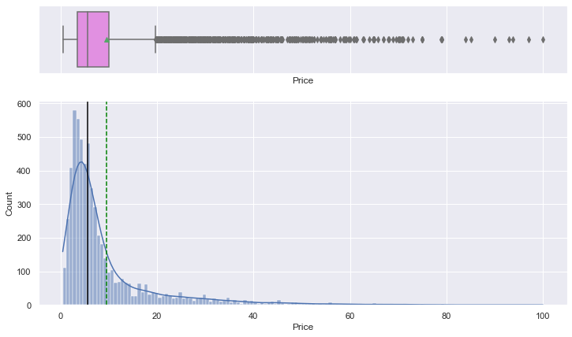

```python
# check how the distribution of Price may have changed
histogram_boxplot(df2, "Price")
```

The Year column spans a reasonable number of years. The Kilometers_Driven had some extreme values to the right.

It's uncommon and unlikely that cars will reach 325,000 km+ in their lifetime, but it really depends on many factors like how well the car is maintained. We can use the interquartile range as our cutoff point for outliers.

```python
# find the values that are greater than 4*IQR from the median
quartiles = np.quantile(
    df2["Kilometers_Driven"][df2["Kilometers_Driven"].notnull()], [0.25, 0.75]
)
km_4iqr = 4 * (quartiles[1] - quartiles[0])
outlier_km = df2.loc[
    np.abs(df2["Kilometers_Driven"] - df2["Kilometers_Driven"].median()) > km_4iqr,
    "Kilometers_Driven",
]
print(outlier_km.sort_values(ascending=False).count() / df2.shape[0] * 100, "%")
df2.loc[outlier_km.sort_values().index]
```

```
0.4819677580189463 %
```

|  | Name | Location | Year | Kilometers_Driven | Fuel_Type | Transmission | Owner_Type | Mileage | Engine | Power | Seats | New_Price | Price | Make |
| --- | --- | --- | --- | --- | --- | --- | --- | --- | --- | --- | --- | --- | --- | --- |
| 5800 | Toyota Innova 2.5 VX (Diesel) 7 Seater BS IV | Hyderabad | 2012 | 210000 | Diesel | Manual | First | 12.99 | 2494.0 | 100.00 | 7.0 | 24.010 | 9.00 | toyota |
| 838 | Mahindra Xylo H4 | Chennai | 2016 | 215000 | Diesel | Manual | First | 14.02 | 2179.0 | 118.30 | 7.0 | 11.670 | 7.50 | mahindra |
| 2267 | Toyota Qualis RS E2 | Pune | 2004 | 215750 | Diesel | Manual | Second | 0.00 | 2446.0 | NaN | 10.0 | 24.010 | 3.50 | toyota |
| 181 | Ford Fiesta 1.4 TDCi EXI Limited Edition | Chennai | 2006 | 216000 | Diesel | Manual | Second | 17.80 | 1399.0 | 68.00 | 5.0 | 11.685 | 1.45 | ford |
| 1766 | Mercedes-Benz New C-Class C 200 Kompressor Ele... | Pune | 2007 | 220000 | Petrol | Automatic | Second | 11.74 | 1796.0 | 186.00 | 5.0 | 49.490 | 6.00 | mercedes-benz |
| 1068 | Toyota Etios Liva GD | Pune | 2012 | 225000 | Diesel | Manual | Second | 23.59 | 1364.0 | NaN | 5.0 | 8.525 | 2.60 | toyota |
| 5647 | Toyota Qualis Fleet A3 | Mumbai | 2001 | 227000 | Diesel | Manual | Fourth & Above | 0.00 | 2446.0 | NaN | 8.0 | 24.010 | 2.20 | toyota |
| 77 | Toyota Innova 2.0 G1 | Chennai | 2006 | 230000 | Petrol | Manual | Third | 12.40 | 1998.0 | 132.00 | 8.0 | 24.010 | 4.50 | toyota |
| 1442 | Honda City 1.5 S MT | Delhi | 2009 | 231673 | Petrol | Manual | First | 17.00 | 1497.0 | 118.00 | 5.0 | 13.580 | 2.60 | honda |
| 3713 | Chevrolet Captiva LT | Jaipur | 2009 | 232000 | Diesel | Manual | First | 11.50 | 1991.0 | 147.90 | 7.0 | 11.300 | 3.50 | chevrolet |
| 2346 | Mahindra Xylo D2 BSIV | Chennai | 2013 | 234000 | Diesel | Manual | Second | 14.00 | 2489.0 | 95.00 | 8.0 | 11.670 | 3.50 | mahindra |
| 2988 | Toyota Innova 2.5 G4 Diesel 8-seater | Chennai | 2005 | 240000 | Diesel | Manual | Fourth & Above | 12.80 | 2494.0 | 102.00 | 8.0 | 24.010 | 5.10 | toyota |
| 4792 | Toyota Fortuner 3.0 Diesel | Chennai | 2010 | 242000 | Diesel | Manual | First | 11.50 | 2982.0 | 171.00 | 7.0 | 37.170 | 11.00 | toyota |
| 1101 | Toyota Innova 2.5 V Diesel 7-seater | Chennai | 2011 | 248000 | Diesel | Manual | Second | 12.80 | 2494.0 | 102.00 | 7.0 | 24.010 | 9.20 | toyota |
| 4719 | Toyota Innova 2.5 GX (Diesel) 8 Seater | Chennai | 2014 | 250000 | Diesel | Manual | First | 12.99 | 2494.0 | 100.60 | 8.0 | 24.010 | 10.90 | toyota |
| 3894 | Toyota Innova 2.5 GX 7 STR | Hyderabad | 2010 | 250000 | Diesel | Manual | Second | 12.80 | 2494.0 | 102.00 | 7.0 | 24.010 | 6.50 | toyota |
| 5834 | Toyota Innova 2.5 G (Diesel) 8 Seater | Jaipur | 2013 | 250000 | Diesel | Manual | Second | 12.99 | 2494.0 | 100.60 | 8.0 | 24.010 | 7.90 | toyota |
| 1846 | Toyota Innova 2.5 GX (Diesel) 7 Seater | Pune | 2013 | 255000 | Diesel | Manual | Third | 12.99 | 2494.0 | 100.60 | 7.0 | 24.010 | 6.50 | toyota |
| 29 | Toyota Innova 2.5 V Diesel 7-seater | Mumbai | 2007 | 262000 | Diesel | Manual | Fourth & Above | 12.80 | 2494.0 | 102.00 | 7.0 | 24.010 | 4.00 | toyota |
| 1975 | Skoda Superb 1.8 TSI MT | Pune | 2012 | 282000 | Petrol | Manual | First | 13.14 | 1798.0 | 160.00 | 5.0 | 33.360 | 3.30 | skoda |
| 1528 | Toyota Innova 2.5 G (Diesel) 8 Seater BS IV | Hyderabad | 2005 | 299322 | Diesel | Manual | First | 12.80 | 2494.0 | 102.00 | 8.0 | 24.010 | 4.00 | toyota |
| 3649 | Tata Indigo LS | Jaipur | 2008 | 300000 | Diesel | Manual | First | 17.00 | 1405.0 | 70.00 | 5.0 | 7.630 | 1.00 | tata |
| 4491 | Hyundai i20 Magna Optional 1.2 | Bangalore | 2013 | 445000 | Petrol | Manual | First | 18.50 | 1197.0 | 82.90 | 5.0 | 10.250 | 4.45 | hyundai |
| 2823 | Volkswagen Jetta 2013-2015 2.0L TDI Highline AT | Chennai | 2015 | 480000 | Diesel | Automatic | First | 16.96 | 1968.0 | 138.03 | 5.0 | 10.150 | 13.00 | volkswagen |
| 3092 | Honda City i VTEC SV | Kolkata | 2015 | 480000 | Petrol | Manual | First | 17.40 | 1497.0 | 117.30 | 5.0 | 13.580 | 5.00 | honda |
| 358 | Hyundai i10 Magna 1.2 | Chennai | 2009 | 620000 | Petrol | Manual | First | 20.36 | 1197.0 | 78.90 | 5.0 | 10.250 | 2.70 | hyundai |
| 1860 | Volkswagen Vento Diesel Highline | Chennai | 2013 | 720000 | Diesel | Manual | First | 20.54 | 1598.0 | 103.60 | 5.0 | 13.230 | 5.90 | volkswagen |
| 340 | Skoda Octavia Ambition Plus 2.0 TDI AT | Kolkata | 2013 | 775000 | Diesel | Automatic | First | 19.30 | 1968.0 | 141.00 | 5.0 | 25.830 | 7.50 | skoda |
| 2328 | BMW X5 xDrive 30d M Sport | Chennai | 2017 | 6500000 | Diesel | Automatic | First | 15.97 | 2993.0 | 258.00 | 5.0 | 55.070 | 65.00 | bmw |

The number of rows that are more than 4*IQR from the median only make up less than 0.49% of data. So, these rows can be dropped without too much loss of data.

```python
# drop outliers in Kilometers_Driven
df2 = df2[~df2.index.isin(list(outlier_km.index))]
```

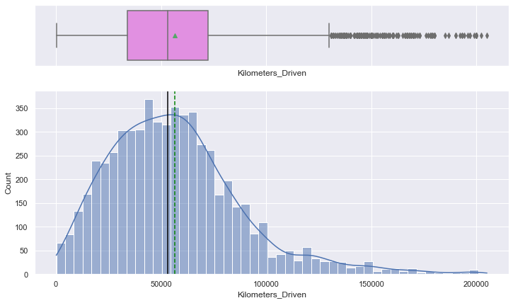

```python
# check the distribution
histogram_boxplot(df2, "Kilometers_Driven")
```

The Mileage column looks normally distributed, but it had some 0 values. This is an unexpected value since this column represents the standard mileage offered by the car company. We will replace these with the average mileage by make of a car.

```python
# replace 0 values in Mileage column with the average mileage by make
df2["Mileage"] = df2["Mileage"].replace(0.0, np.nan)
df2["Mileage"].fillna(
    value=df2.groupby(["Make"])["Mileage"].transform(np.mean), inplace=True
)
```

```
7.5
```

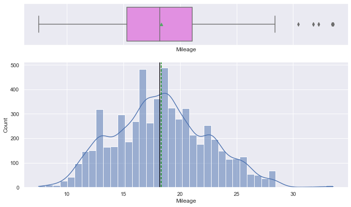

```python
# check the min value of mileage and see the distribution
histogram_boxplot(data=df2, feature="Mileage")
df2.Mileage.min()
```

The distribution still appears normally distributed.

Engine and Power columns were both skewed. We know that traditionally, a car with a bigger engine would generate more power than a car with a smaller engine. So we can use their relationship to identify any outliers.

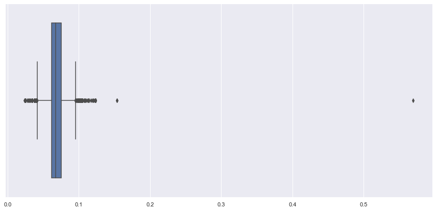

```python
# check the distribution of Power over Engine
plt.figure(figsize=(15, 7))
sns.boxplot((df2.Power / df2.Engine))
```

There appears to be one outlying point that is much further from the rest. We will look into this more.

```python
df2["Power_Engine"] = df2.Power / df2.Engine
df2.sort_values(by="Power_Engine", ascending=False).head()
```

|  | Name | Location | Year | Kilometers_Driven | Fuel_Type | Transmission | Owner_Type | Mileage | Engine | Power | Seats | New_Price | Price | Make | Power_Engine |
| --- | --- | --- | --- | --- | --- | --- | --- | --- | --- | --- | --- | --- | --- | --- | --- |
| 4446 | Mahindra E Verito D4 | Chennai | 2016 | 50000 | Electric | Automatic | First | 15.171685 | 72.0 | 41.00 | 5.0 | 13.580 | 13.00 | mahindra | 0.569444 |
| 4061 | Audi RS5 Coupe | Mumbai | 2013 | 23312 | Petrol | Automatic | First | 11.050000 | 2894.0 | 444.00 | 4.0 | 128.000 | 40.50 | audi | 0.153421 |
| 148 | Audi RS5 Coupe | Mumbai | 2013 | 23000 | Petrol | Automatic | First | 11.050000 | 2894.0 | 444.00 | 4.0 | 128.000 | 37.00 | audi | 0.153421 |
| 4065 | Ford Ecosport 1.0 Ecoboost Titanium | Kochi | 2014 | 43316 | Petrol | Manual | First | 18.880000 | 999.0 | 123.37 | 5.0 | 11.685 | 6.22 | ford | 0.123493 |
| 389 | Jaguar XE Portfolio | Mumbai | 2017 | 9000 | Petrol | Automatic | First | 13.500000 | 1999.0 | 246.74 | 5.0 | 53.720 | 34.50 | jaguar | 0.123432 |

A Google search of the first 3 values shows that the first is incorrect, but the next two have correct engine and power values. We will correct the value of the first row.

```python
# replace first row's value with value found in Google
df2.loc[4446, "Engine"] = 1461
df2.sort_values(by="Power_Engine", ascending=False).head(1)
```

|  | Name | Location | Year | Kilometers_Driven | Fuel_Type | Transmission | Owner_Type | Mileage | Engine | Power | Seats | New_Price | Price | Make | Power_Engine |
| --- | --- | --- | --- | --- | --- | --- | --- | --- | --- | --- | --- | --- | --- | --- | --- |
| 4446 | Mahindra E Verito D4 | Chennai | 2016 | 50000 | Electric | Automatic | First | 15.171685 | 1461.0 | 41.0 | 5.0 | 13.58 | 13.0 | mahindra | 0.569444 |

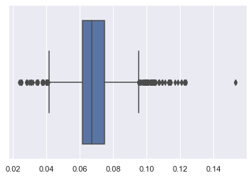

```python
# let's see the distribution after dropping the values
sns.boxplot((df2.Power / df2.Engine))
df2.drop("Power_Engine", axis=1, inplace=True)
```

The Seats column had a few cars with 0 seats, which is not reasonable. Some cars had 10 seats, and from a Google search, that is possible.

```python
# find the cars that had 0 seats.
df2[df2.Seats == 0]
```

|  | Name | Location | Year | Kilometers_Driven | Fuel_Type | Transmission | Owner_Type | Mileage | Engine | Power | Seats | New_Price | Price | Make |
| --- | --- | --- | --- | --- | --- | --- | --- | --- | --- | --- | --- | --- | --- | --- |
| 3999 | Audi A4 3.2 FSI Tiptronic Quattro | Hyderabad | 2012 | 125000 | Petrol | Automatic | First | 10.5 | 3197.0 | NaN | 0.0 | 53.14 | 18.0 | audi |

From a Google search, this car should have 5 seats, so we will replace it with that value.

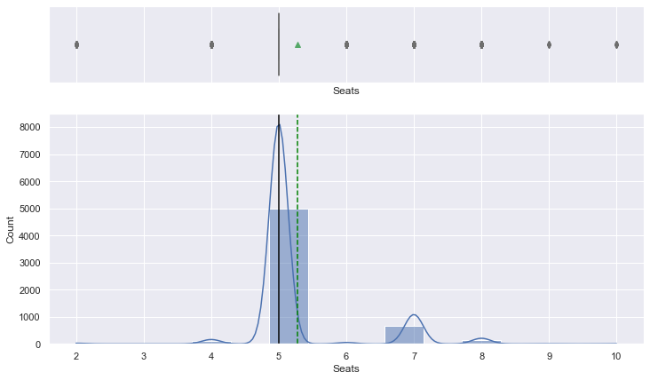

```python
# replace 0 value in Seats column
df2["Seats"] = df2["Seats"].replace(0.0, 5.0)
histogram_boxplot(df2, "Seats")
```

The New_Price column also had a couple of extreme values.

```python
# look at the highest priced cars
df2.sort_values(by="New_Price", ascending=False).head()
```

|  | Name | Location | Year | Kilometers_Driven | Fuel_Type | Transmission | Owner_Type | Mileage | Engine | Power | Seats | New_Price | Price | Make |
| --- | --- | --- | --- | --- | --- | --- | --- | --- | --- | --- | --- | --- | --- | --- |
| 5521 | Bentley Continental Flying Spur | Hyderabad | 2006 | 48000 | Petrol | Automatic | First | 8.6 | 5998.0 | 552.00 | 4.0 | 375.0 | 59.00 | bentley |
| 4674 | Mercedes-Benz S-Class 280 AT | Kochi | 2004 | 119859 | Petrol | Automatic | First | 13.0 | 2987.0 | 210.00 | 5.0 | 171.0 | 7.10 | mercedes-benz |
| 4778 | Mercedes-Benz S-Class S 350 d | Bangalore | 2011 | 47140 | Diesel | Automatic | Second | 13.5 | 2925.0 | 281.61 | 5.0 | 171.0 | 30.00 | mercedes-benz |
| 3939 | Mercedes-Benz S-Class 320 L | Mumbai | 2006 | 30000 | Petrol | Manual | First | 13.0 | 2987.0 | 210.00 | 5.0 | 171.0 | 10.75 | mercedes-benz |
| 4245 | Mercedes-Benz S-Class 320 L | Coimbatore | 2007 | 84143 | Petrol | Manual | First | 13.0 | 2987.0 | 210.00 | 5.0 | 171.0 | 17.09 | mercedes-benz |

```python
# the price of the Bentley is too high based on google search and there is only one of them. so we will drop this value
df2.drop(axis=0, index=5521, inplace=True)
```

## Bivariate Analysis

Let's see how Price is influenced by the independent variables.

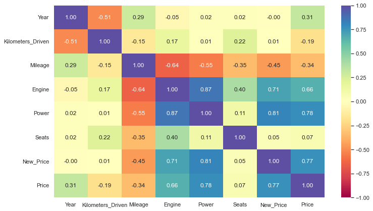

```python
# creating a list of numerical columns and checking correlation
corr_cols = df2.dtypes[(df2.dtypes == np.number) | (df2.dtypes == np.int64)].index
plt.figure(figsize=(12, 7))
sns.heatmap(
    df2[corr_cols].corr(), annot=True, vmin=-1, vmax=1, fmt=".2f", cmap="Spectral"
)
```

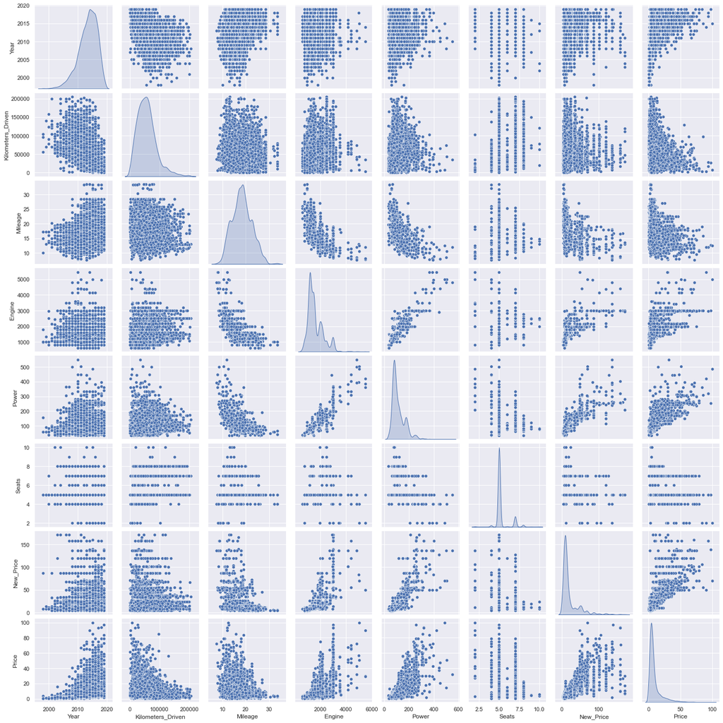

```python
# plot numerical variables against each other
sns.pairplot(data=df2[corr_cols], diag_kind="kde")
```

- The Price column is highly correlated with New_Price, Power, and Engine columns
- Power and New_Price are highly correlated.
- Power and Engine columns are highly correlated with each other, so we will want to drop one of them for linear regression.
- Some of the relationships, like Engine or Power vs. Mileage appear more non-linear than linear.

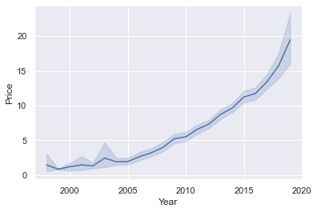

```python
# see how the used car price varies with Year car is manufactured
sns.lineplot(data=df2, x="Year", y="Price")
```

Cars manufactured more recently sell for higher.

Let's see how Price is affected by the categorical variables.

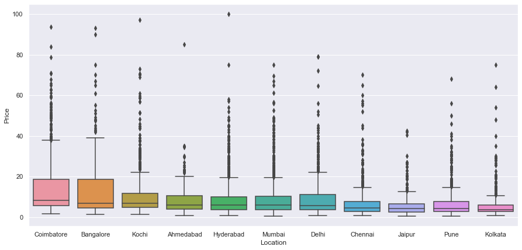

```python
# Price vs. Location
plt.figure(figsize=(15, 7))
sns.boxplot(
    x="Location",
    y="Price",
    data=df2,
    order=df2.groupby("Location")["Price"].median().sort_values(ascending=False).index,
)
```

- Bangalore and Coimbatore cover a large interquartile range of prices compared to other locations.
- The median price is similar across Cities, with Kolkata, Pune, and Jaipur with the lowest values.

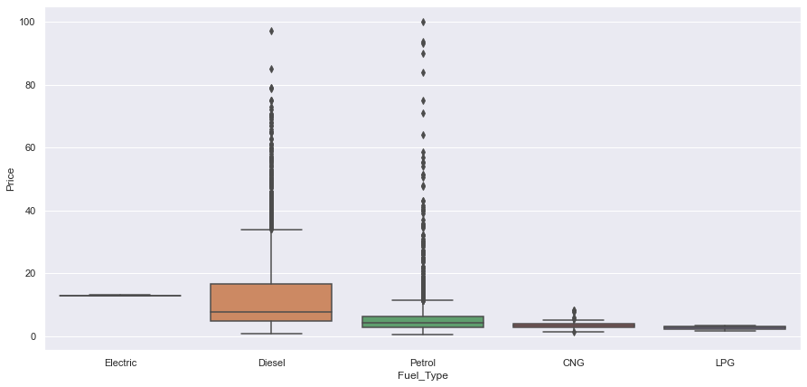

```python
# Price vs. Fuel_Type
plt.figure(figsize=(15, 7))
sns.boxplot(
    x="Fuel_Type",
    y="Price",
    data=df2,
    order=df2.groupby("Fuel_Type")["Price"].median().sort_values(ascending=False).index,
)
```

- Very few cars are electric, so the spread is small, but they have the highest median price.
- Diesel cars tend to be more expensive than Petrol cars.
- CNG and LPG are the least expensive cars.

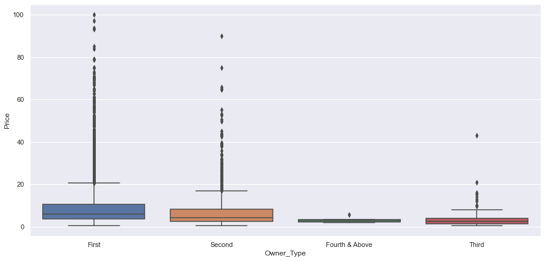

```python
# Price vs. Owner_Type
plt.figure(figsize=(15, 7))
sns.boxplot(
    x="Owner_Type",
    y="Price",
    data=df2,
    order=df2.groupby("Owner_Type")["Price"]
    .median()
    .sort_values(ascending=False)
    .index,
)
```

- It makes sense that prices for cars with one owner will be more epensive than the rest.
- There is a lot of variability in prices for cars that had 3 owners, and the median price is similar to cars with 4 or more owners.

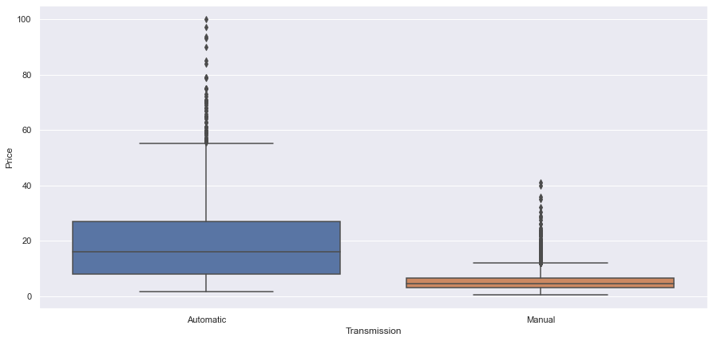

```python
# Price vs. Transmission
plt.figure(figsize=(15, 7))
sns.boxplot(
    x="Transmission",
    y="Price",
    data=df2,
    order=df2.groupby("Transmission")["Price"]
    .median()
    .sort_values(ascending=False)
    .index,
)
```

Automatic cars are clearly priced higher than manual cars.

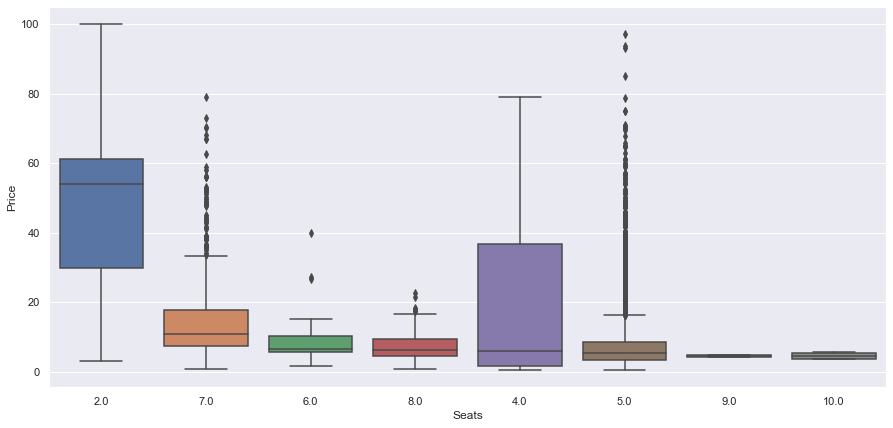

```python
# Price vs. Seats
plt.figure(figsize=(15, 7))
sns.boxplot(
    x=df2["Seats"],
    y="Price",
    data=df2,
    order=df2.groupby("Seats")["Price"].median().sort_values(ascending=False).index,
)
```

- Cars with 2 seats have the highest median price.
- Cars with 9 or 10 seats have the lowest median price.
- Prices for cars with 5 seats span a wide range, maybe becuase it is the most common.

[output not shown]

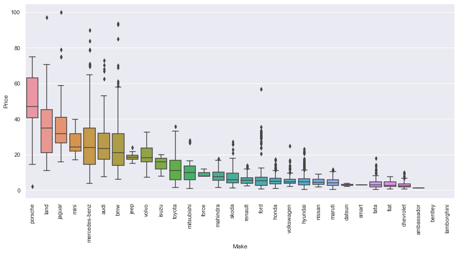

```python
# Price vs. Make
plt.figure(figsize=(15, 7))
sns.boxplot(
    x="Make",
    y="Price",
    data=df2,
    order=df2.groupby("Make")["Price"].median().sort_values(ascending=False).index,
)
plt.xticks(rotation=90)
```

- Cars from Porshe have the highest median price, followed by Land Rover.
- The median prices are similar from around Renault and lower.
- Chevrolet, Fiat, and Ambassador have the lowest median prices of used cars.